# Brolucizumab Study Report

Indexa Geodata

2024-06-04

# General descriptions of the data.

Count of women and men in the sample:

| sexo_cat | N |
| --- | --- |
| Mujer | 6 |
| Hombre | 17 |

Counting of patients according to age:

| edad | N |
| --- | --- |
| 82 | 2 |
| 73 | 2 |
| 74 | 1 |
| 88 | 4 |
| 69 | 1 |
| 87 | 3 |
| 72 | 1 |
| 77 | 3 |
| 78 | 1 |
| 83 | 1 |

[output cut: 4 more lines]

Analyzed eye count (Right / Left):

| ojo | N |
| --- | --- |
| 0 | 11 |
| 1 | 12 |

## Display of records.

| paciente_id | fecha_inicio | fecha_fin | tiempo_meses | farmaco | n_inyecciones | precio_1_inyeccion | gasto_total_inyecciones | gasto_acto_inyectar | n_revisiones | gasto_revisiones_oct | av | av_sin_tto | av_pre_brolu | av_post_brolu_1mes | av_post_brolu_6m | av_post_brolu_12m | resolucion_1m | resolucion_12m |
| --- | --- | --- | --- | --- | --- | --- | --- | --- | --- | --- | --- | --- | --- | --- | --- | --- | --- | --- |
| PAC_0001 | 2022-07-25 | 2022-12-07 | 4 | Ranibizumab | 3 | 212 | 636 | 163.74 | 2 | 348.96 | 0.32 | 0.32 |  | 0 | 0 | 0 |  |  |
| PAC_0001 | 2022-12-07 | 2023-05-30 | 6 | Aflibercept | 3 | 136.5 | 409.5 | 163.74 | 1 | 174.48 | 0.3 | 0 | 0.3 | 0 | 0 | 0 |  |  |
| PAC_0001 | 2023-05-30 | 2023-10-26 | 5 | Brolucizumab | 3 | 218 | 654 | 163.74 | 4 | 697.92 | 0.3 | 0 | 0 | 0.4 | 0.3 | 0.2 | 0 | 0 |
| PAC_0001 | 2023-10-26 | 2024-05-30 | 7 | Faricimab | 6 | 93 | 558 | 327.48 | 3 | 523.44 | 0.3 | 0 | 0 | 0 | 0 | 0 |  |  |
| PAC_0002 | 2022-06-15 | 2022-11-09 | 5 | Ranibizumab | 2 | 212 | 424 | 109.16 | 2 | 348.96 | 0.5 | 0.32 |  | 0 | 0 | 0 |  |  |
| PAC_0002 | 2022-11-09 | 2023-05-25 | 7 | Aflibercept | 3 | 136.5 | 409.5 | 218.32 | 1 | 174.48 | 0.32 | 0 | 0.32 | 0 | 0 | 0 |  |  |
| PAC_0002 | 2023-05-25 | 2024-03-05 | 9 | Brolucizumab | 1 | 218 | 218 | 54.58 | 3 | 523.44 | 0.1 | 0 | 0 | 0.12 | 0.1 | 0.1 | 0 | 0 |
| PAC_0002 | 2024-03-05 | 2024-05-25 | 3 | Faricimab | 3 | 93 | 279 | 163.74 | 1 | 174.48 | 0 | 0 | 0 | 0 | 0 | 0 |  |  |
| PAC_0003 | 2022-06-07 | 2023-01-18 | 7 | Aflibercept | 4 | 136.5 | 546 | 218.32 | 3 | 523.44 | 0.4 | 0.3 | 0.4 | 0 | 0 | 0 |  |  |
| PAC_0003 | 2023-01-18 | 2024-01-18 | 12 | Brolucizumab | 2 | 218 | 436 | 109.16 | 4 | 697.92 | 0.5 | 0 | 0 | 0.6 | 0.3 | 0.5 | 0 | 0 |

[output cut: 64 more lines]

## Movements between drugs.

Taken from the previous records. Faricimab does not register movements between drugs because it is the last treatment.

| paciente_id | farmaco_1 | farmaco_2 | tiempo_far1_meses | coste_inicio | coste_fin | av_inicio | av_fin |
| --- | --- | --- | --- | --- | --- | --- | --- |
| PAC_0001 | Sin Tratamiento | Ranibizumab | 0 | 0 | 1148.7 | 0.32 | 0.32 |
| PAC_0001 | Ranibizumab | Aflibercept | 4 | 1148.7 | 747.72 | 0.32 | 0.3 |
| PAC_0001 | Aflibercept | Brolucizumab | 6 | 747.72 | 1515.66 | 0.3 | 0.3 |
| PAC_0001 | Brolucizumab | Faricimab | 5 | 1515.66 | 1408.92 | 0.3 | 0.3 |
| PAC_0002 | Sin Tratamiento | Ranibizumab | 0 | 0 | 882.12 | 0.32 | 0.5 |
| PAC_0002 | Ranibizumab | Aflibercept | 5 | 882.12 | 802.3 | 0.5 | 0.32 |
| PAC_0002 | Aflibercept | Brolucizumab | 7 | 802.3 | 796.02 | 0.32 | 0.1 |
| PAC_0002 | Brolucizumab | Faricimab | 10 | 796.02 | 617.22 | 0.1 | 0 |
| PAC_0003 | Sin Tratamiento | Aflibercept | 0 | 0 | 1287.76 | 0.3 | 0.4 |
| PAC_0003 | Aflibercept | Brolucizumab | 8 | 1287.76 | 1243.08 | 0.4 | 0.5 |

[output cut: 64 more lines]

## Evolution of the VA in patients.

Taken from the previous records.

**Evolution of the VA in Women. Mes_fin and Mes_inicio show the month in which brolu began and ended**

| paciente_id | mes_fin | av | inicio_brolu | fin_brolu |
| --- | --- | --- | --- | --- |
| PAC_0001 | 0 | 0.32 | 10 | 15 |
| PAC_0001 | 4 | 0.32 | 10 | 15 |
| PAC_0001 | 10 | 0.3 | 10 | 15 |
| PAC_0001 | 15 | 0.3 | 10 | 15 |
| PAC_0001 | 22 | 0.3 | 10 | 15 |
| PAC_0003 | 0 | 0.3 | 7 | 19 |
| PAC_0003 | 7 | 0.4 | 7 | 19 |
| PAC_0003 | 19 | 0.5 | 7 | 19 |
| PAC_0013 | 0 | 0.13 | 12 | 20 |
| PAC_0013 | 5 | 0.32 | 12 | 20 |

[output cut: 14 more lines]

[figure not shown]

**Evolution of the VA in Men. Mes_fin and Mes_inicio show the month in which brolu began and ended. First 8 patients registered**.

| paciente_id | mes_fin | av | inicio_brolu | fin_brolu |
| --- | --- | --- | --- | --- |
| PAC_0002 | 0 | 0.32 | 12 | 21 |
| PAC_0002 | 5 | 0.5 | 12 | 21 |
| PAC_0002 | 12 | 0.32 | 12 | 21 |
| PAC_0002 | 21 | 0.1 | 12 | 21 |
| PAC_0002 | 24 | 0 | 12 | 21 |
| PAC_0004 | 0 | 0.15 | 10 | 22 |
| PAC_0004 | 5 | 0.2 | 10 | 22 |
| PAC_0004 | 10 | 0.2 | 10 | 22 |
| PAC_0004 | 22 | 0.2 | 10 | 22 |
| PAC_0005 | 0 | 0.32 | 11 | 21 |

[output cut: 21 more lines]

[figure not shown]

**Evolution of the VA in Men. Mes_fin and Mes_inicio show the month in which brolu began and ended. Rest**.

| paciente_id | mes_fin | av | inicio_brolu | fin_brolu |
| --- | --- | --- | --- | --- |
| PAC_0011 | 0 | 0.25 | 11 | 19 |
| PAC_0011 | 6 | 0.2 | 11 | 19 |
| PAC_0011 | 11 | 0.12 | 11 | 19 |
| PAC_0011 | 19 | 0.16 | 11 | 19 |
| PAC_0011 | 23 | 0.1 | 11 | 19 |
| PAC_0012 | 0 | 0.2 | 9 | 21 |
| PAC_0012 | 4 | 0.32 | 9 | 21 |
| PAC_0012 | 9 | 0.2 | 9 | 21 |
| PAC_0012 | 21 | 0.2 | 9 | 21 |
| PAC_0015 | 0 | 0.2 | 10 | 11 |

[output cut: 32 more lines]

[figure not shown]

## Changes to Faricimab. List of demographic variables and adverse effects.

### Changes to Faricimab.

**Change to Faricimab**

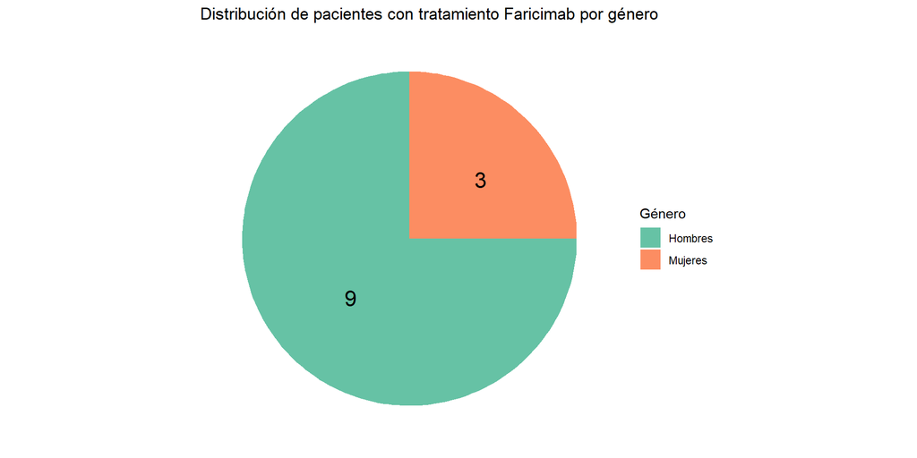

### Adverse effects

**Data.**

| PACIENTE_ID | SEXO | EDAD | OJO | InflamaciónIntraocular | Opacidadesvítreas |
| --- | --- | --- | --- | --- | --- |
| PAC_0001 | 1 | 82 | 0 | 0 | 0 |
| PAC_0002 | 0 | 73 | 1 | 0 | 0 |
| PAC_0003 | 1 | 74 | 1 | 0 | 0 |
| PAC_0004 | 0 | 88 | 1 | 0 | 0 |
| PAC_0005 | 0 | 69 | 1 | 0 | 0 |
| PAC_0006 | 0 | 87 | 0 | 0 | 1 |
| PAC_0007 | 0 | 73 | 0 | 0 | 0 |
| PAC_0008 | 0 | 72 | 0 | 0 | 1 |
| PAC_0009 | 0 | 87 | 1 | 0 | 0 |
| PAC_0010 | 0 | 88 | 0 | 0 | 0 |

[output cut: 13 more lines]

**Graphical representation**

[figure not shown]

# Cost-effectiveness analysis.

## Movements according to the sample. Drug changes.

Table of movements/changes of the sample with their transition probabilities, which can be interpreted as percentages of patients who perform this drug change according to the sample (23 patients).

| farmaco_1 | farmaco_2 | n | n_move | prob_trans | cond_dist_prob |
| --- | --- | --- | --- | --- | --- |
| Ranibizumab | Ranibizumab | 15 | 0 | 0 | 1 |
| Ranibizumab | Aflibercept | 15 | 8 | 0.5333333333333333 | 1 |
| Ranibizumab | Brolucizumab | 15 | 6 | 0.4 | 1 |
| Ranibizumab | Faricimab | 15 | 1 | 0.06666666666666667 | 1 |
| Aflibercept | Ranibizumab | 24 | 6 | 0.25 | 1 |
| Aflibercept | Aflibercept | 22 | 0 | 0 | 1 |
| Aflibercept | Brolucizumab | 24 | 17 | 0.7083333333333334 | 1 |
| Aflibercept | Faricimab | 24 | 1 | 0.04166666666666666 | 1 |
| Brolucizumab | Ranibizumab | 23 | 1 | 0.04347826086956522 | 1 |
| Brolucizumab | Aflibercept | 23 | 1 | 0.04347826086956522 | 1 |

[output cut: 6 more lines]

### Transition matrix and number of patients.

The transition probabilities (shown above) are usually shown as a matrix, in addition, a matrix has been added that collects the count of patients who perform the drug change shown in the row-column.

Transition Matrix (Probabilities)

|  | Ranibizumab | Aflibercept | Brolucizumab | Faricimab |
| --- | --- | --- | --- | --- |
| Ranibizumab | 0.0000000 | 0.5333333 | 0.4000000 | 0.0666667 |
| Aflibercept | 0.2500000 | 0.0000000 | 0.7083333 | 0.0416667 |
| Brolucizumab | 0.0434783 | 0.0434783 | 0.4782609 | 0.4347826 |
| Faricimab | 0.0000000 | 0.0000000 | 0.0000000 | 1.0000000 |

Transition Matrix (Nº of movements)

|  | Ranibizumab | Aflibercept | Brolucizumab | Faricimab |
| --- | --- | --- | --- | --- |
| Ranibizumab | 0 | 8 | 6 | 1 |
| Aflibercept | 6 | 0 | 17 | 1 |
| Brolucizumab | 1 | 1 | 11 | 10 |
| Faricimab | 0 | 0 | 0 | 0 |

### Graphic representation.

It is necessary to take into account that the values have been rounded.

[interactive chart not shown]

Conclusions of the patient sample:

- 40% of patients who have treatment with Ranibizumab, switch to treatment with Brolucizumab.
- 71% of patients who are treated with Aflibercept are switched to treatment with Brolucizumab.
- Between Aflibercept and Ranibizumab, it is observed that 53% of Ranibizumab patients switch to Aflibercept and 25% of Aflibercept to Ranibizumab.
- 48% of patients with Brolucizumab remain on the same treatment, and 43% (approximately) have changed to Faricimab.

## Costs and Effectiveness. Definition.

- Average patient costs according to the sample:

| farmaco | gasto_medio_inyecciones | gasto_medio_inyectar | gasto_medio_rev |
| --- | --- | --- | --- |
| Aflibercept | 511.875 | 206.9491666666667 | 336.6941666666667 |
| Brolucizumab | 606.6086956521739 | 156.6208695652174 | 864.8139130434782 |
| Faricimab | 271.25 | 159.1916666666667 | 232.64 |
| Ranibizumab | 739.0933333333334 | 203.7653333333333 | 294.4386666666667 |

- Mean VA variation of patients in each drug according to the sample: (Negative variations are not taken into account, since the disease is degenerative).

| farmaco | media_av_variacion | sd_av_variacion |
| --- | --- | --- |
| Ranibizumab | 0.08275 | 0.1091613692908556 |
| Aflibercept | 0.05805555555555555 | 0.08198168534511928 |
| Brolucizumab | 0.035 | 0.06085697518420899 |
| Faricimab | 0.02 | 0.04472135954999579 |

- Percentage of patients with an improvement or no worsening. That is, any record with a non-variation or positive variation by drug.

| farmaco | porcentaje_mejora |
| --- | --- |
| Ranibizumab | 66.66666666666666 |
| Aflibercept | 62.5 |
| Brolucizumab | 56.52173913043478 |
| Faricimab | 66.66666666666666 |

- Summary of costs and effectiveness. Complete table.

| farmaco | gasto_medio_inyecciones | gasto_medio_inyectar | gasto_medio_rev | media_av_variacion | sd_av_variacion | porcentaje_mejora |
| --- | --- | --- | --- | --- | --- | --- |
| Aflibercept | 511.875 | 206.9491666666667 | 336.6941666666667 | 0.05805555555555555 | 0.08198168534511928 | 62.5 |
| Brolucizumab | 606.6086956521739 | 156.6208695652174 | 864.8139130434782 | 0.035 | 0.06085697518420899 | 56.52173913043478 |
| Faricimab | 271.25 | 159.1916666666667 | 232.64 | 0.02 | 0.04472135954999579 | 66.66666666666666 |
| Ranibizumab | 739.0933333333334 | 203.7653333333333 | 294.4386666666667 | 0.08275 | 0.1091613692908556 | 66.66666666666666 |

## Model of Markov. Why doesn't it work?

- The treatments do not coincide in duration.
- The injections also do not have an established period, but in 3 months you can have 3 or 1 injection depending on the known situation with the OCT.
- The injections and the duration time directly and indirectly influence the costs and effectiveness means assigned to patients, this means that the interpretations and results that Markov would give were not completely generalizable.

## Comparisons between the number of injections, reviews and duration of treatment.

[figure not shown]

[figure not shown]

It can be observed that the difference in mean time in one treatment and the average number of injections is much higher in Brolucizumab than in other treatments. This, together with the previous conclusion, shows that in a treatment with Brolucizumab the number of injections administered to patients is lower than in other treatments and, therefore, in relation to the costs per injection / act of injection, Brolucizumab could be cheaper. This will be studied later in the cost-effectiveness analysis.

For example, if we set a number of injections for each treatment, we could observe how the behavior of each treatment in relation to the number of reviews and the average number of months in which only 3 injections are given.

[figure not shown]

In the same line as the previous conclusions, for a common number of injections, Brolucizumab registers more reviews to control the disease, and at the same time the treatment period for 3 injections is longer on average than in the other treatments with different drugs.

With all this, after observing the 3 comparisons, it is concluded that at the level of the number of injections Brolucizumab is much lower than the rest, which could influence it to be cheaper, but the number of reviews that are performed is much higher per injection, which negatively influences costs making it more expensive. In addition, the average time of a patient on treatment with Brolucizumab is longer than the average time on any other treatment with another drug.

## Alternative I to Markov: Calculation of the ICER with estimated values of the sample.

In this study, due to the nature of the data, the ICER indicator does not offer information that is entirely relevant to the objective of comparing the cost-benefit of the treatment of Brolucizumab versus the standard treatments Aflibercept and Ranibizumab, since they do not share the same period of stay in each treatment. However, it gives us a general idea of what is observed in the sample, and therefore what would be expected in other situations.

The approach at this point is similar to the one that follows the construction of the ICER indicator, the variations in cost and effectiveness will be analyzed (taking as a measure of effectiveness the percentage of improvement of the treatments according to the variation of the VA in the treatment period) considering the total average expenditure on each drug and the average expenditure disaggregated by type of cost.

Both in this alternative and in the next one, the variations in costs and effectiveness will be interpreted, leaving the ICER for the final conclusions to be able to draw comparative interpretations according to the expenses and alternatives.

*Interpretation of cost-effectiveness*

- More Cost-Effective: Indicates that treatment provides greater health improvement per unit of cost. This is generally desirable because it means that resources are being used efficiently to maximize benefits for patients.
- Less Cost-Effective: Indicates that the treatment provides less improvement in health per unit of cost, which may not be a good use of resources, especially if there are more cost-effective alternatives available.

### ICER without cost breakdown.

| farmaco_exp | farmaco_control | var_coste | var_efectividad | ICER |
| --- | --- | --- | --- | --- |
| Aflibercept | Ranibizumab | -181.779 | -4.166666666666657 | 43.6269600000001 |
| Aflibercept | Brolucizumab | -572.5251449275361 | 5.978260869565219 | -95.76784242424237 |
| Brolucizumab | Ranibizumab | 390.7461449275361 | -10.14492753623188 | -38.51640571428573 |
| Brolucizumab | Aflibercept | 572.5251449275361 | -5.978260869565219 | -95.76784242424237 |
| Ranibizumab | Aflibercept | 181.779 | 4.166666666666657 | 43.6269600000001 |
| Ranibizumab | Brolucizumab | -390.7461449275361 | 10.14492753623188 | -38.51640571428573 |

1. Aflibercept vs. Ranibizumab:
   - Var_cost = -$181.78.
   - Var_effectiveness = -4.17.
   - The ICER is approximately $43.63.
   - In conclusion, Ranibizumab is more expensive but is more effective.
2. Aflibercept vs. Brolucizumab:
   - Var_cost = -$572.53.
   - Var_effectiveness = 5.98.
   - The ICER is approximately -$95.77.
   - Aflibercept is cheaper and more effective than Brolucizumab, according to the patient sample.
   - In other words, Aflibercept is not only more effective but also reduces costs compared to Brolucizumab, providing a better cost-effectiveness ratio.
3. Brolucizumab vs. Ranibizumab:
   - Var_cost = $390.75.
   - Var_effectiveness = -10.14.
   - The ICER is approximately -$38.52.
   - Brolucizumab is more expensive and less effective than Ranibizumab.
   - In other words, Ranibizumab is not only more effective but also reduces costs compared to Brolucizumab, providing a better cost-effectiveness ratio.

### ICER disaggregated by type of cost.

**ICER Average cost according to the number of injections of patients in the treatments:**

| farmaco_exp | farmaco_control | var_coste | var_efectividad | ICER |
| --- | --- | --- | --- | --- |
| Aflibercept | Ranibizumab | -227.2183333333334 | -4.166666666666657 | 54.53240000000013 |
| Aflibercept | Brolucizumab | -94.73369565217388 | 5.978260869565219 | -15.84636363636363 |
| Brolucizumab | Ranibizumab | -132.4846376811595 | -10.14492753623188 | 13.05920000000002 |
| Brolucizumab | Aflibercept | 94.73369565217388 | -5.978260869565219 | -15.84636363636363 |
| Ranibizumab | Aflibercept | 227.2183333333334 | 4.166666666666657 | 54.53240000000013 |
| Ranibizumab | Brolucizumab | 132.4846376811595 | 10.14492753623188 | 13.05920000000002 |

1. Aflibercept vs. Ranibizumab (Injections):
   - Var_cost = -$227.22.
   - Var_effectiveness = -4.17.
   - ICER = $54.53.
   - **Interpretation**: The cost of Aflibercept injections is lower, but its effectiveness also decreases.
2. Brolucizumab vs. Ranibizumab (Injections):
   - Var_cost = -$132.48.
   - Var_effectiveness = -10.14.
   - ICER = 13.06.
   - **Interpretation**: The cost of Brolucizumab injections is lower, but its effectiveness also decreases significantly.
3. Brolucizumab vs. Aflibercept (Injections):
   - Var_cost = $94.73.
   - Var_effectiveness = -5.98.
   - ICER = -$15.85.
   - **Interpretation**: In terms of number of injections, the average cost of Brolucizumab injections is higher than the average cost of injections of Aflibercept according to the sample, and the effectiveness with Brolucizumab is lower.

**ICER Average cost according to the complete expenses in injections (+ drug dosage consultation) of the patients in the treatments:**

| farmaco_exp | farmaco_control | var_coste | var_efectividad | ICER |
| --- | --- | --- | --- | --- |
| Aflibercept | Ranibizumab | -224.0345000000001 | -4.166666666666657 | 53.76828000000015 |
| Aflibercept | Brolucizumab | -44.40539855072461 | 5.978260869565219 | -7.427812121212115 |
| Brolucizumab | Ranibizumab | -179.6291014492755 | -10.14492753623188 | 17.70629714285717 |
| Brolucizumab | Aflibercept | 44.40539855072461 | -5.978260869565219 | -7.427812121212115 |
| Ranibizumab | Aflibercept | 224.0345000000001 | 4.166666666666657 | 53.76828000000015 |
| Ranibizumab | Brolucizumab | 179.6291014492755 | 10.14492753623188 | 17.70629714285717 |

1. Aflibercept vs. Ranibizumab:
   - Var_cost = -$224.03.
   - Var_effectiveness = -4.17.
   - ICER = $53.77.
   - **Interpretation**: Aflibercept is less effective and cheaper when only the costs of injections and consultations for their administration are considered.
2. Brolucizumab vs. Ranibizumab:
   - Var_cost = -$179.63.
   - Var_effectiveness = -10.14.
   - ICER = $17.71.
   - **Interpretation**: The cost of Brolucizumab is lower than that of Ranibizumab when both injections and consultations for its administration are considered, but its effectiveness decreases significantly.
3. Brolucizumab vs. Aflibercept:
   - Var_cost = $44.41.
   - Var_effectiveness = -5.98.
   - ICER = -$7.43.
   - **Interpretation**: Brolucizumab has a higher cost than Aflibercept when both injections and administration consultations are considered, and also shows a lower effectiveness.

**ICER Average cost per number of patient reviews in treatments:**

| farmaco_exp | farmaco_control | var_coste | var_efectividad | ICER |
| --- | --- | --- | --- | --- |
| Aflibercept | Ranibizumab | 42.25549999999998 | -4.166666666666657 | -10.14132000000002 |
| Aflibercept | Brolucizumab | -528.1197463768116 | 5.978260869565219 | -88.34003030303028 |
| Brolucizumab | Ranibizumab | 570.3752463768116 | -10.14492753623188 | -56.2227028571429 |
| Brolucizumab | Aflibercept | 528.1197463768116 | -5.978260869565219 | -88.34003030303028 |
| Ranibizumab | Aflibercept | -42.25549999999998 | 4.166666666666657 | -10.14132000000002 |
| Ranibizumab | Brolucizumab | -570.3752463768116 | 10.14492753623188 | -56.2227028571429 |

1. Aflibercept vs. Ranibizumab:
   - Var_cost = $42.26.
   - Var_effectiveness = -4.17.
   - ICER = -$10.14.
   - **Interpretation**: Aflibercept has a higher cost in number of revisions compared to Ranibizumab.
2. Brolucizumab vs. Ranibizumab:
   - Var_cost = $570.38.
   - Var_effectiveness = -10.14.
   - ICER = -$56.22.
   - **Interpretation**: Brolucizumab has a much higher cost in number of reviews compared to Ranibizumab.
3. Brolucizumab vs. Aflibercept:
   - Var_cost = $528.12.
   - Var_effectiveness = -5.98.
   - ICER = -$88.34
   - **Interpretation**: Brolucizumab has a higher cost in number of reviews and a lower effectiveness compared to Aflibercept.

#### General conclusions of the breakdowns.

| farmaco_exp | farmaco_control | ICER_revis | ICER_inyec | ICER_total_inyec | ICER_total |
| --- | --- | --- | --- | --- | --- |
| Aflibercept | Brolucizumab | -88.34003030303028 | -15.84636363636363 | -7.427812121212115 | -95.76784242424237 |
| Aflibercept | Ranibizumab | -10.14132000000002 | 54.53240000000013 | 53.76828000000015 | 43.6269600000001 |
| Brolucizumab | Aflibercept | -88.34003030303028 | -15.84636363636363 | -7.427812121212115 | -95.76784242424237 |
| Brolucizumab | Ranibizumab | -56.2227028571429 | 13.05920000000002 | 17.70629714285717 | -38.51640571428573 |
| Ranibizumab | Aflibercept | -10.14132000000002 | 54.53240000000013 | 53.76828000000015 | 43.6269600000001 |
| Ranibizumab | Brolucizumab | -56.2227028571429 | 13.05920000000002 | 17.70629714285717 | -38.51640571428573 |

**They are analyzed in comparison with alternative II in the final conclusions**

## Alternative II to Markov: ICER with the monthly rates calculated from the sample. Simulating a 6-month treatment with each drug.

For this alternative we will calculate the monthly rates of injection, review and VA variation for each drug. This is something like what is expected to vary monthly each of these aspects according to the sample collected.

Thanks to these rates of variation, the ICER indicator can be interpreted assuming a common number of months in each drug, providing more specific interpretations.

This alternative gives us a more generalized vision and allows us, from the values of the rates, to obtain total expenses and estimated variations in the different ranges of months that we want. At this point, the calculations are made considering that the time in each treatment is **6 months**.

- Average injection rate in each treatment:

| farmaco | tasa_media_inyecc |
| --- | --- |
| Ranibizumab | 0.6622943722943723 |
| Aflibercept | 0.599476911976912 |
| Brolucizumab | 0.3346398770311814 |

- Average rate of reviews in each treatment:

| farmaco | tasa_media_rev |
| --- | --- |
| Ranibizumab | 0.3194805194805195 |
| Aflibercept | 0.4110254329004329 |
| Brolucizumab | 0.5982542819499341 |

- Average rate of variation of AV in each treatment:

| farmaco | tasa_media_av |
| --- | --- |
| Ranibizumab | 0.01561324675324675 |
| Brolucizumab | 0.003493589743589744 |
| Aflibercept | 0.008615151515151515 |

- Complete table. (1 month in each treatment)

| farmaco | tasa_media_inyecc | tasa_media_rev | tasa_media_av | meses |
| --- | --- | --- | --- | --- |
| Aflibercept | 0.599476911976912 | 0.4110254329004329 | 0.008615151515151515 | 1 |
| Brolucizumab | 0.3346398770311814 | 0.5982542819499341 | 0.003493589743589744 | 1 |
| Ranibizumab | 0.6622943722943723 | 0.3194805194805195 | 0.01561324675324675 | 1 |

- Complete table considering 6 months in each treatment. (Multiply each rate by 6).

| farmaco | tasa_media_inyecc | tasa_media_rev | tasa_media_av | meses |
| --- | --- | --- | --- | --- |
| Aflibercept | 3 | 2 | 0.05169090909090909 | 6 |
| Brolucizumab | 2 | 3 | 0.02096153846153846 | 6 |
| Ranibizumab | 3 | 1 | 0.09367948051948052 | 6 |

Therefore, we have the injections, reviews and what is expected to vary the visual acuity if the drug works for each treatment in the same time interval, in 6 months. The calculation of the ICER considering the same time interval of the patient in the drug will be carried out considering the total and disaggregated expenditure.

### ICER without disaggregating.

| farmaco_exp | farmaco_control | var_coste | var_efectividad | ICER |
| --- | --- | --- | --- | --- |
| Aflibercept | Ranibizumab | -52.01999999999998 | -4.198857142857144 | 12.38908546543276 |
| Aflibercept | Brolucizumab | -146.4000000000001 | 3.072937062937063 | -47.64171767972149 |
| Brolucizumab | Ranibizumab | 94.38000000000011 | -7.271794205794206 | -12.97891515202639 |
| Brolucizumab | Aflibercept | 146.4000000000001 | -3.072937062937063 | -47.64171767972149 |
| Ranibizumab | Aflibercept | 52.01999999999998 | 4.198857142857144 | 12.38908546543276 |
| Ranibizumab | Brolucizumab | -94.38000000000011 | 7.271794205794206 | -12.97891515202639 |

1. Aflibercept vs. Ranibizumab:
   - Var_cost: -$52.02.
   - Var_effectiveness: -4.198857.
   - ICER: $12.39.
   - **Interpretation**: Aflibercept shows a lower total monthly cost and a slight decrease in effectiveness compared to Ranibizumab.
2. Aflibercept vs. Brolucizumab:
   - Var_cost: -$146.40.
   - Var_effectiveness: 3.072937.
   - ICER: -$47.64.
   - **Interpretation**: Aflibercept has a significantly lower cost and an improvement in effectiveness compared to Brolucizumab.
3. Brolucizumab vs. Ranibizumab:
   - Var_cost: $94.38.
   - Var_effectiveness: -7.271794.
   - ICER: -$12.98.
   - **Interpretation**: Brolucizumab shows a higher monthly cost and a decrease in effectiveness compared to Ranibizumab.

### ICER disaggregated by type of expenditure.

**ICER Considering the cost of each injection.** ($ injections)

| farmaco_exp | farmaco_control | var_coste | var_efectividad | ICER |
| --- | --- | --- | --- | --- |
| Aflibercept | Ranibizumab | -226.5 | -4.198857142857144 | 53.94324986390853 |
| Aflibercept | Brolucizumab | -26.5 | 3.072937062937063 | -8.623671574539745 |
| Brolucizumab | Ranibizumab | -200 | -7.271794205794206 | 27.50352861204995 |
| Brolucizumab | Aflibercept | 26.5 | -3.072937062937063 | -8.623671574539745 |
| Ranibizumab | Aflibercept | 226.5 | 4.198857142857144 | 53.94324986390853 |
| Ranibizumab | Brolucizumab | 200 | 7.271794205794206 | 27.50352861204995 |

1. Aflibercept vs. Ranibizumab:
   - Var_cost: -$226.50.
   - Var_effectiveness: -4.198857.
   - ICER: $53.94.
   - **Interpretation**: Aflibercept has a lower monthly cost in terms of injections and a slight decrease in effectiveness compared to Ranibizumab.
2. Aflibercept vs. Brolucizumab:
   - Var_cost: -$26.50.
   - Var_effectiveness: 3.072937.
   - ICER: -$8.62.
   - **Interpretation**: Aflibercept has a lower monthly cost in injections and shows an improvement in effectiveness compared to Brolucizumab.
3. Brolucizumab vs. Ranibizumab:
   - Var_cost: -$200.00.
   - Var_effectiveness: -7.271794.
   - ICER: $27.50.
   - **Interpretation**: Brolucizumab shows a lower monthly cost in injections but a greater decrease in effectiveness compared to Ranibizumab.

**ICER Considering the full cost in injections.** ($ injections + dosage consultation)

| farmaco_exp | farmaco_control | var_coste | var_efectividad | ICER |
| --- | --- | --- | --- | --- |
| Aflibercept | Ranibizumab | -226.5 | -4.198857142857144 | 53.94324986390853 |
| Aflibercept | Brolucizumab | 28.08000000000004 | 3.072937062937063 | 9.137837653323638 |
| Brolucizumab | Ranibizumab | -254.58 | -7.271794205794206 | 35.00924157027838 |
| Brolucizumab | Aflibercept | -28.08000000000004 | -3.072937062937063 | 9.137837653323638 |
| Ranibizumab | Aflibercept | 226.5 | 4.198857142857144 | 53.94324986390853 |
| Ranibizumab | Brolucizumab | 254.58 | 7.271794205794206 | 35.00924157027838 |

1. Aflibercept vs. Ranibizumab:
   - Var_cost: -$226.50.
   - Var_effectiveness: -4.198857.
   - ICER: $53.94.
   - **Interpretation**: Aflibercept is cheaper and less effective than Ranibizumab.
2. Aflibercept vs. Brolucizumab:
   - Var_cost: $28.08.
   - Var_effectiveness: 3.072937.
   - ICER: $9.14.
   - **Interpretation**: Aflibercept has a slightly higher total cost in terms of injections, but shows an improvement in effectiveness compared to Brolucizumab.
3. Brolucizumab vs. Ranibizumab:
   - Var_cost: -$254.58.
   - Var_effectiveness: -7.271794.
   - ICER: $35.01.
   - **Interpretation**: Brolucizumab shows a lower total monthly cost in injections and consultations but a greater decrease in effectiveness compared to Ranibizumab.

**ICER Considering the cost of revisions.**

| farmaco_exp | farmaco_control | var_coste | var_efectividad | ICER |
| --- | --- | --- | --- | --- |
| Aflibercept | Ranibizumab | 174.48 | -4.198857142857144 | -41.55416439847577 |
| Aflibercept | Brolucizumab | -174.48 | 3.072937062937063 | -56.77955533304509 |
| Brolucizumab | Ranibizumab | 348.96 | -7.271794205794206 | -47.98815672230476 |
| Brolucizumab | Aflibercept | 174.48 | -3.072937062937063 | -56.77955533304509 |
| Ranibizumab | Aflibercept | -174.48 | 4.198857142857144 | -41.55416439847577 |
| Ranibizumab | Brolucizumab | -348.96 | 7.271794205794206 | -47.98815672230476 |

1. Aflibercept vs. Ranibizumab:
   - Var_cost: $174.48.
   - Var_effectiveness: -4.198857.
   - ICER: -$41.55.
   - **Interpretation**: Aflibercept shows a higher cost in reviews and a slight decrease in effectiveness compared to Ranibizumab.
2. Aflibercept vs. Brolucizumab:
   - Var_cost: -$174.48.
   - Var_effectiveness: 3.072937.
   - ICER: -$56.78.
   - **Interpretation**: Aflibercept has a lower monthly cost in reviews and shows an improvement in effectiveness compared to Brolucizumab.
3. Brolucizumab vs. Ranibizumab:
   - Var_cost: $348.96.
   - Var_effectiveness: -7.271794.
   - ICER: -$47.99.
   - **Interpretation**: Brolucizumab shows a higher monthly cost in reviews and a greater decrease in effectiveness compared to Ranibizumab.

#### General conclusions of the disaggregation

| farmaco_exp | farmaco_control | ICER_revis | ICER_inyec | ICER_total_inyec | ICER_total |
| --- | --- | --- | --- | --- | --- |
| Aflibercept | Brolucizumab | -56.77955533304509 | -8.623671574539745 | 9.137837653323638 | -47.64171767972149 |
| Aflibercept | Ranibizumab | -41.55416439847577 | 53.94324986390853 | 53.94324986390853 | 12.38908546543276 |
| Brolucizumab | Aflibercept | -56.77955533304509 | -8.623671574539745 | 9.137837653323638 | -47.64171767972149 |
| Brolucizumab | Ranibizumab | -47.98815672230476 | 27.50352861204995 | 35.00924157027838 | -12.97891515202639 |
| Ranibizumab | Aflibercept | -41.55416439847577 | 53.94324986390853 | 53.94324986390853 | 12.38908546543276 |
| Ranibizumab | Brolucizumab | -47.98815672230476 | 27.50352861204995 | 35.00924157027838 | -12.97891515202639 |

## General conclusions with the 2 alternatives.

In summary, while the ICER offers a simplified measure of the incremental cost-effectiveness relationship between treatments, variations in cost and effectiveness provide a more detailed perspective on how costs and effectiveness vary between treatments. Both approaches to interpreting are correct.

**The ICER will be interpreted above all because it has greater interpretative complexity.**

### Comparison of results on total expenditure.

| farmaco_exp | farmaco_control | var_coste_Muestra | var_coste_6m | var_efect_Muestra | var_efect_6m | ICER_M | ICER_6m |
| --- | --- | --- | --- | --- | --- | --- | --- |
| Aflibercept | Brolucizumab | -572.5251449275361 | -146.4000000000001 | 5.978260869565219 | 3.072937062937063 | -95.76784242424237 | -47.64171767972149 |
| Aflibercept | Ranibizumab | -181.779 | -52.01999999999998 | -4.166666666666657 | -4.198857142857144 | 43.6269600000001 | 12.38908546543276 |
| Brolucizumab | Aflibercept | 572.5251449275361 | 146.4000000000001 | -5.978260869565219 | -3.072937062937063 | -95.76784242424237 | -47.64171767972149 |
| Brolucizumab | Ranibizumab | 390.7461449275361 | 94.38000000000011 | -10.14492753623188 | -7.271794205794206 | -38.51640571428573 | -12.97891515202639 |
| Ranibizumab | Aflibercept | 181.779 | 52.01999999999998 | 4.166666666666657 | 4.198857142857144 | 43.6269600000001 | 12.38908546543276 |
| Ranibizumab | Brolucizumab | -390.7461449275361 | -94.38000000000011 | 10.14492753623188 | 7.271794205794206 | -38.51640571428573 | -12.97891515202639 |

### Comparison of results on number of injections

| farmaco_exp | farmaco_control | var_coste_Muestra | var_coste_6m | var_efect_Muestra | var_efect_6m | ICER_M | ICER_6m |
| --- | --- | --- | --- | --- | --- | --- | --- |
| Aflibercept | Brolucizumab | -94.73369565217388 | -26.5 | 5.978260869565219 | 3.072937062937063 | -15.84636363636363 | -8.623671574539745 |
| Aflibercept | Ranibizumab | -227.2183333333334 | -226.5 | -4.166666666666657 | -4.198857142857144 | 54.53240000000013 | 53.94324986390853 |
| Brolucizumab | Aflibercept | 94.73369565217388 | 26.5 | -5.978260869565219 | -3.072937062937063 | -15.84636363636363 | -8.623671574539745 |
| Brolucizumab | Ranibizumab | -132.4846376811595 | -200 | -10.14492753623188 | -7.271794205794206 | 13.05920000000002 | 27.50352861204995 |
| Ranibizumab | Aflibercept | 227.2183333333334 | 226.5 | 4.166666666666657 | 4.198857142857144 | 54.53240000000013 | 53.94324986390853 |
| Ranibizumab | Brolucizumab | 132.4846376811595 | 200 | 10.14492753623188 | 7.271794205794206 | 13.05920000000002 | 27.50352861204995 |

In this case, considering the cost only for the purchase of the injection, the cost-effectiveness ratio follows the same line as the general. Concluding that Brolucizumab is less cost-effective than the rest.

**Impact of Injection Costs**:

- For Aflibercept vs. Brolucizumab, although Brolucizumab has a slightly higher initial cost, simulating for 6 months, the difference in costs is reduced. However, Brolucizumab is still less cost-effective.
- For Ranibizumab vs. Brolucizumab, Brolucizumab has lower costs both in the initial sample and simulating for 6 months. However, its lower effectiveness generates a positive ICER, indicating lower cost-effectiveness.

**Final Conclusion**

By considering only the costs of injections, Brolucizumab has a less favorable cost-effectiveness profile compared to Aflibercept and Ranibizumab. Although the costs of injections are lower for Brolucizumab compared to Ranibizumab, its lower effectiveness compensates for this cost advantage, resulting in a positive ECER that indicates lower cost-effectiveness. Compared to Aflibercept, Brolucizumab remains less cost-effective both in the initial sample and projected at 6 months.

These results reinforce the conclusion that, despite some lower costs, the lower effectiveness of Brolucizumab makes it a less favorable option in terms of cost-effectiveness compared to Aflibercept and Ranibizumab.

### Comparison of results on total expenditure on injections.

| farmaco_exp | farmaco_control | var_coste_Muestra | var_coste_6m | var_efect_Muestra | var_efect_6m | ICER_M | ICER_6m |
| --- | --- | --- | --- | --- | --- | --- | --- |
| Aflibercept | Brolucizumab | -44.40539855072461 | 28.08000000000004 | 5.978260869565219 | 3.072937062937063 | -7.427812121212115 | 9.137837653323638 |
| Aflibercept | Ranibizumab | -224.0345000000001 | -226.5 | -4.166666666666657 | -4.198857142857144 | 53.76828000000015 | 53.94324986390853 |
| Brolucizumab | Aflibercept | 44.40539855072461 | -28.08000000000004 | -5.978260869565219 | -3.072937062937063 | -7.427812121212115 | 9.137837653323638 |
| Brolucizumab | Ranibizumab | -179.6291014492755 | -254.58 | -10.14492753623188 | -7.271794205794206 | 17.70629714285717 | 35.00924157027838 |
| Ranibizumab | Aflibercept | 224.0345000000001 | 226.5 | 4.166666666666657 | 4.198857142857144 | 53.76828000000015 | 53.94324986390853 |
| Ranibizumab | Brolucizumab | 179.6291014492755 | 254.58 | 10.14492753623188 | 7.271794205794206 | 17.70629714285717 | 35.00924157027838 |

In this case, we find some variation in results when performing a projection at 6 months in each treatment. Let's look at each objective comparison:

**Brolucizumab vs. Aflibercept**

- Injection and administration costs:
  - Initial sample: Brolucizumab has a slightly higher cost than Aflibercept, with a variation of 44.4054.
  - 6 months: Projecting to 6 months, the cost is reduced compared to Aflibercept, with a variation of -28.08.
- Effectiveness:
  - Initial sample: Brolucizumab has a lower effectiveness, with a variation of -5.978261.
  - 6 months: This difference in effectiveness is slightly reduced to -3.072937.
- ICER:
  - Initial sample: -7.427812, indicating that Brolucizumab is less cost-effective.
  - 6 months: 9.137838, suggesting that, at 6 months, Brolucizumab could be more cost-effective due to cost reduction.

**Brolucizumab v.s. Ranibizumab**.

**Impact of the cost of injection and drug administration**:

- For Aflibercept vs. Brolucizumab, although Brolucizumab has a slightly higher initial cost, projecting at 6 months, the reduction in costs makes Brolucizumab more cost-effective.
- For Ranibizumab vs. Brolucizumab, Brolucizumab has lower costs both in the initial sample and projecting at 6 months. However, its lower effectiveness generates a positive ICER, indicating lower cost-effectiveness.

**Final conclusion:**

By considering exclusively the costs of injections and administration, Brolucizumab has a more favorable cost-effectiveness profile at 6 months compared to Aflibercept, but is still less cost-effective than Ranibizumab due to its lower effectiveness. In the initial sample, Brolucizumab is less cost-effective in both comparisons. Therefore, while there are some improvements in the cost-effectiveness profile of Brolucizumab, it is still less cost-effective compared to Ranibizumab, although it may have advantages over Aflibercept when considering an equal time horizon for all drugs.

### Comparison of results on revision spending.

| farmaco_exp | farmaco_control | var_coste_Muestra | var_coste_6m | var_efect_Muestra | var_efect_6m | ICER_M | ICER_6m |
| --- | --- | --- | --- | --- | --- | --- | --- |
| Aflibercept | Brolucizumab | -528.1197463768116 | -174.48 | 5.978260869565219 | 3.072937062937063 | -88.34003030303028 | -56.77955533304509 |
| Aflibercept | Ranibizumab | 42.25549999999998 | 174.48 | -4.166666666666657 | -4.198857142857144 | -10.14132000000002 | -41.55416439847577 |
| Brolucizumab | Aflibercept | 528.1197463768116 | 174.48 | -5.978260869565219 | -3.072937062937063 | -88.34003030303028 | -56.77955533304509 |
| Brolucizumab | Ranibizumab | 570.3752463768116 | 348.96 | -10.14492753623188 | -7.271794205794206 | -56.2227028571429 | -47.98815672230476 |
| Ranibizumab | Aflibercept | -42.25549999999998 | -174.48 | 4.166666666666657 | 4.198857142857144 | -10.14132000000002 | -41.55416439847577 |
| Ranibizumab | Brolucizumab | -570.3752463768116 | -348.96 | 10.14492753623188 | 7.271794205794206 | -56.2227028571429 | -47.98815672230476 |

In this case, in relation to the costs of reviews that occur in each treatment, the conclusions on Brolucizumab continue to go in the same line as the general conclusions for the total expenses shown above, concluding that treatment with Brolucizumab is less cost-effective than the others.

**Impact of Review Costs**:

- Review costs are a significant factor in the lower cost-effectiveness of Brolucizumab. Even when considering only review costs, Brolucizumab is still less cost-effective than Aflibercept and Ranibizumab.
- The difference in review costs contributes to a negative ICER, which indicates that Brolucizumab increases costs while reducing effectiveness.